# Red Wine Quality Analysis by Sen Zhuang

# Univariate Plots Section

```
##  [1] "X"                    "fixed.acidity"        "volatile.acidity"
##  [4] "citric.acid"          "residual.sugar"       "chlorides"
##  [7] "free.sulfur.dioxide"  "total.sulfur.dioxide" "density"
## [10] "pH"                   "sulphates"            "alcohol"
## [13] "quality"
```

```
## 'data.frame':    1599 obs. of  12 variables:
##  $ fixed.acidity       : num  7.4 7.8 7.8 11.2 7.4 7.4 7.9 7.3 7.8 7.5 ...
##  $ volatile.acidity    : num  0.7 0.88 0.76 0.28 0.7 0.66 0.6 0.65 0.58 0.5 ...
##  $ citric.acid         : num  0 0 0.04 0.56 0 0 0.06 0 0.02 0.36 ...
##  $ residual.sugar      : num  1.9 2.6 2.3 1.9 1.9 1.8 1.6 1.2 2 6.1 ...
##  $ chlorides           : num  0.076 0.098 0.092 0.075 0.076 0.075 0.069 0.065 0.073 0.071 ...
##  $ free.sulfur.dioxide : int  11 25 15 17 11 13 15 15 9 17 ...
##  $ total.sulfur.dioxide: int  34 67 54 60 34 40 59 21 18 102 ...
##  $ density             : num  0.998 0.997 0.997 0.998 0.998 ...
##  $ pH                  : num  3.51 3.2 3.26 3.16 3.51 3.51 3.3 3.39 3.36 3.35 ...
##  $ sulphates           : num  0.56 0.68 0.65 0.58 0.56 0.56 0.46 0.47 0.57 0.8 ...
##  $ alcohol             : num  9.4 9.8 9.8 9.8 9.4 9.4 9.4 10 9.5 10.5 ...
##  $ quality             : Factor w/ 6 levels "3","4","5","6",..: 3 3 3 4 3 3 3 5 5 3 ...
```

```
##  fixed.acidity   volatile.acidity  citric.acid    residual.sugar
##  Min.   : 4.60   Min.   :0.1200   Min.   :0.000   Min.   : 0.900
##  1st Qu.: 7.10   1st Qu.:0.3900   1st Qu.:0.090   1st Qu.: 1.900
##  Median : 7.90   Median :0.5200   Median :0.260   Median : 2.200
##  Mean   : 8.32   Mean   :0.5278   Mean   :0.271   Mean   : 2.539
##  3rd Qu.: 9.20   3rd Qu.:0.6400   3rd Qu.:0.420   3rd Qu.: 2.600
##  Max.   :15.90   Max.   :1.5800   Max.   :1.000   Max.   :15.500
##    chlorides       free.sulfur.dioxide total.sulfur.dioxide
##  Min.   :0.01200   Min.   : 1.00       Min.   :  6.00
##  1st Qu.:0.07000   1st Qu.: 7.00       1st Qu.: 22.00
##  Median :0.07900   Median :14.00       Median : 38.00
##  Mean   :0.08747   Mean   :15.87       Mean   : 46.47
##  3rd Qu.:0.09000   3rd Qu.:21.00       3rd Qu.: 62.00
##  Max.   :0.61100   Max.   :72.00       Max.   :289.00
##     density             pH          sulphates         alcohol      quality
##  Min.   :0.9901   Min.   :2.740   Min.   :0.3300   Min.   : 8.40   3: 10
##  1st Qu.:0.9956   1st Qu.:3.210   1st Qu.:0.5500   1st Qu.: 9.50   4: 53
##  Median :0.9968   Median :3.310   Median :0.6200   Median :10.20   5:681
##  Mean   :0.9967   Mean   :3.311   Mean   :0.6581   Mean   :10.42   6:638
##  3rd Qu.:0.9978   3rd Qu.:3.400   3rd Qu.:0.7300   3rd Qu.:11.10   7:199
##  Max.   :1.0037   Max.   :4.010   Max.   :2.0000   Max.   :14.90   8: 18
```

```
##   3   4   5   6   7   8
##  10  53 681 638 199  18
```

```
## [1] 5 6 7 4 8 3
## Levels: 3 4 5 6 7 8
```

All the wines here are acidic with `pH` value ranging from 2.74 to 4.01. The `alcohol` content of these wines has a median of 10.2%, minimum of 8.40% and a maximum of 14.90%

# I would next like to examine the distribution of each variable by plotting histograms.

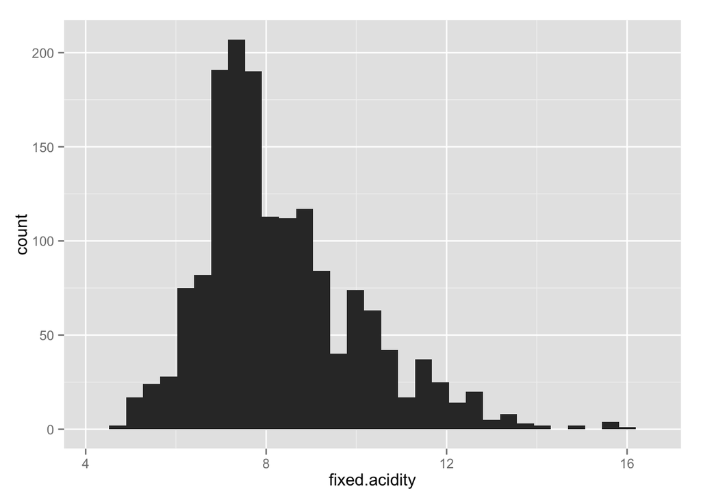

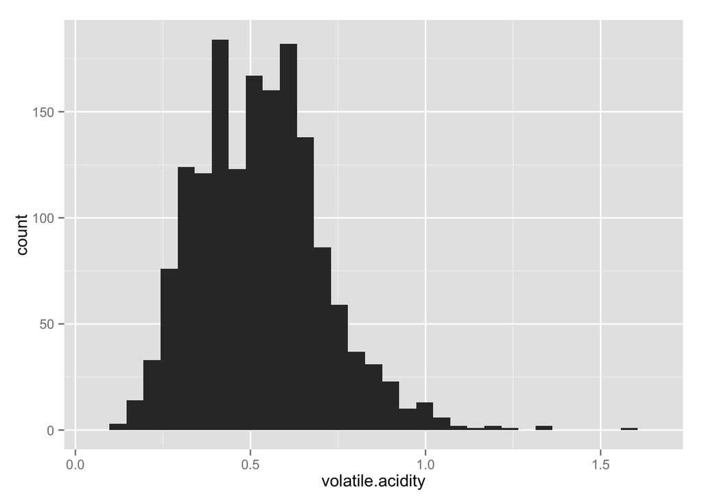

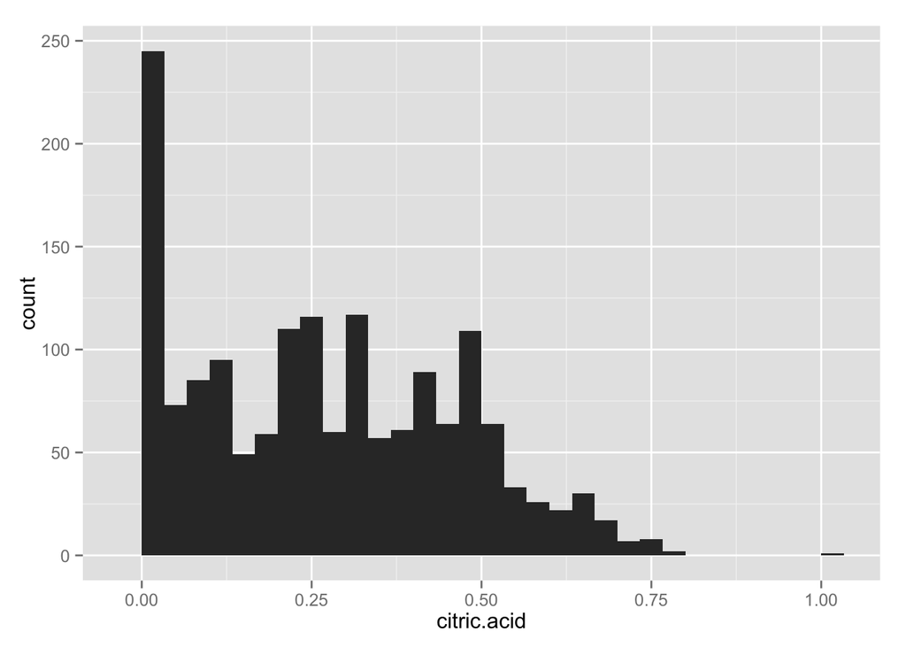

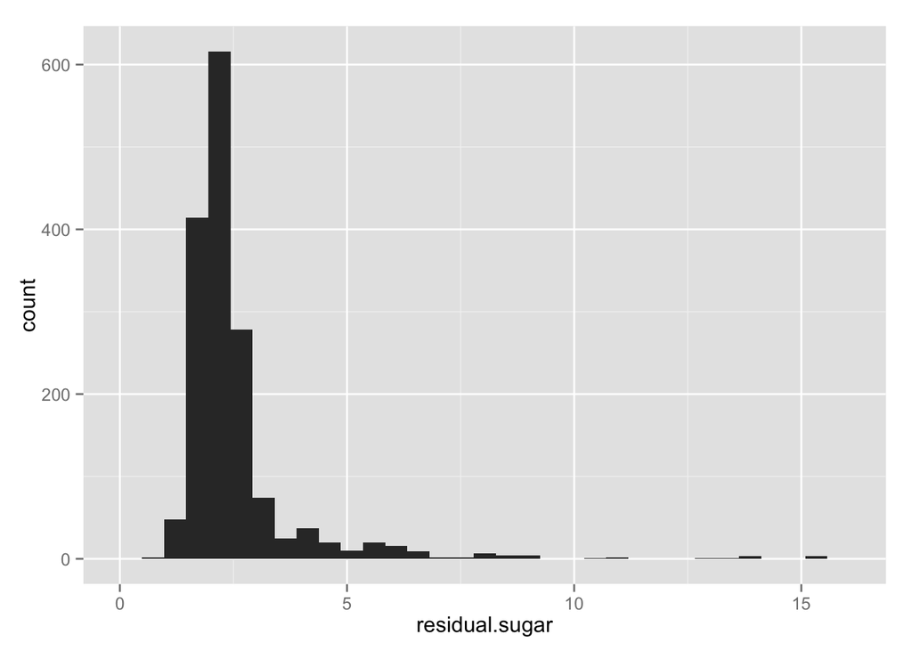

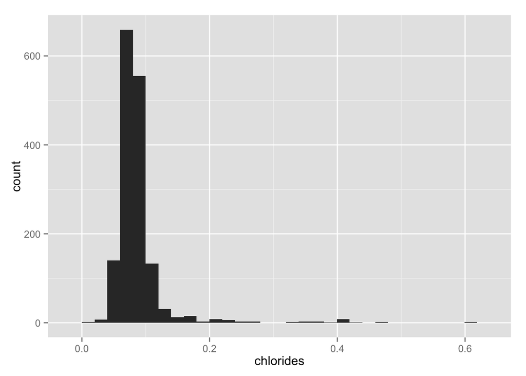

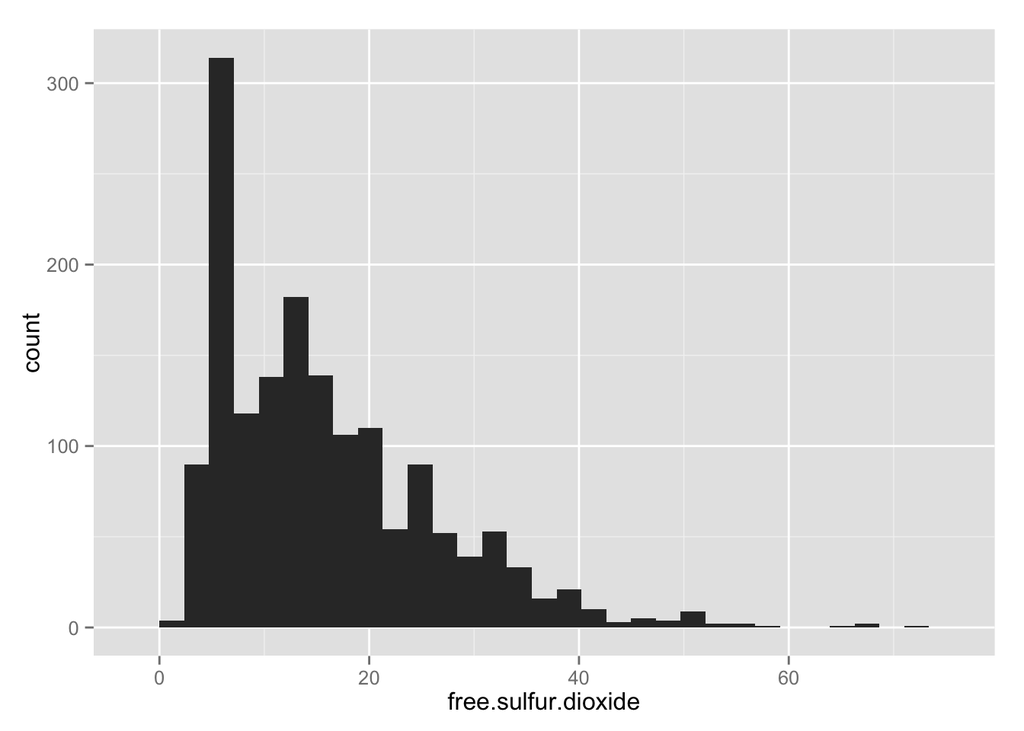

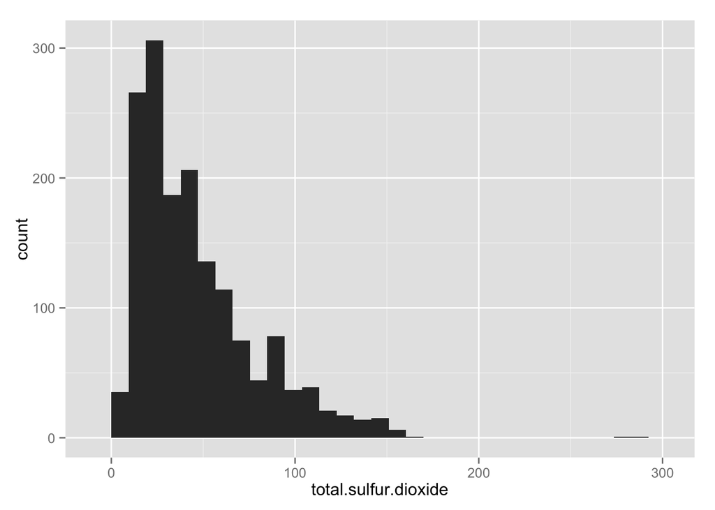

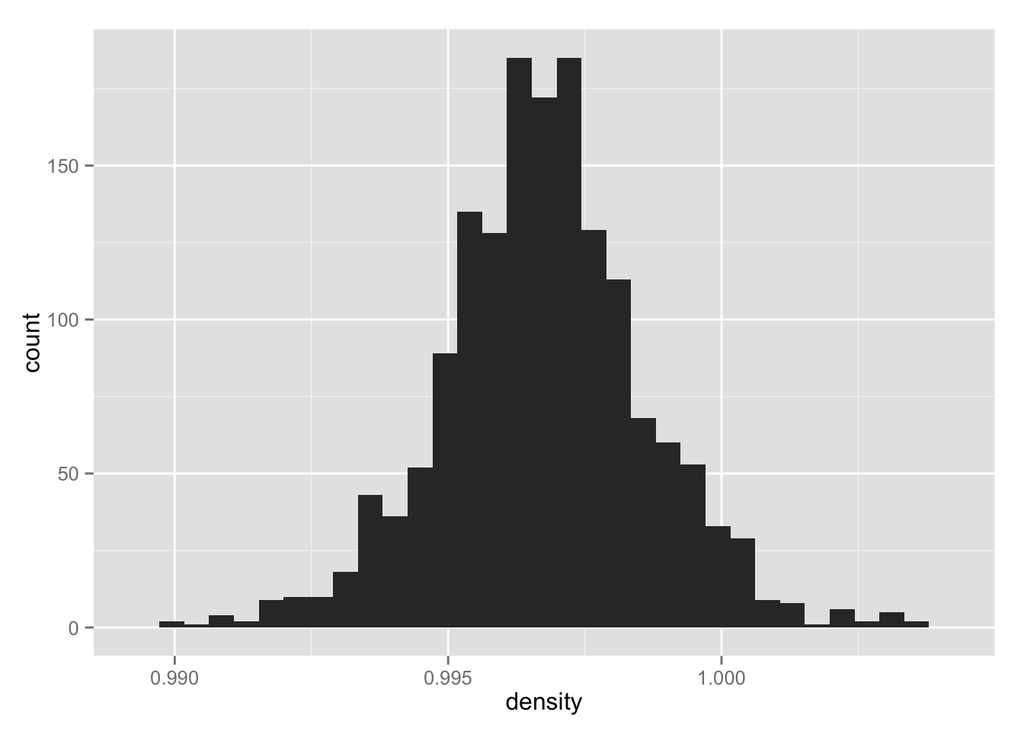

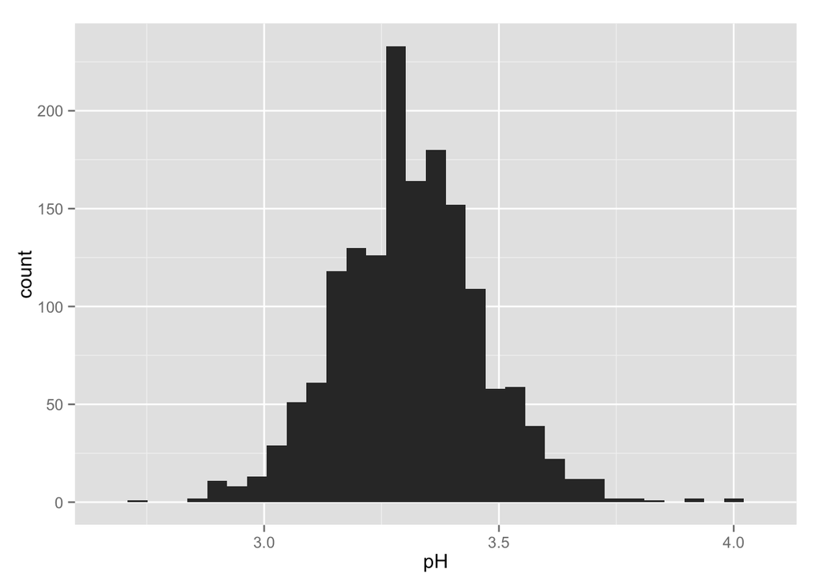

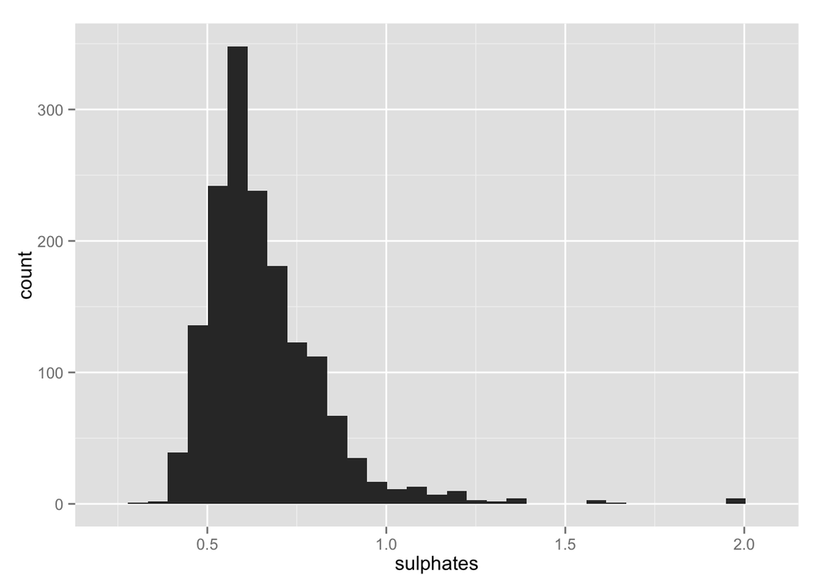

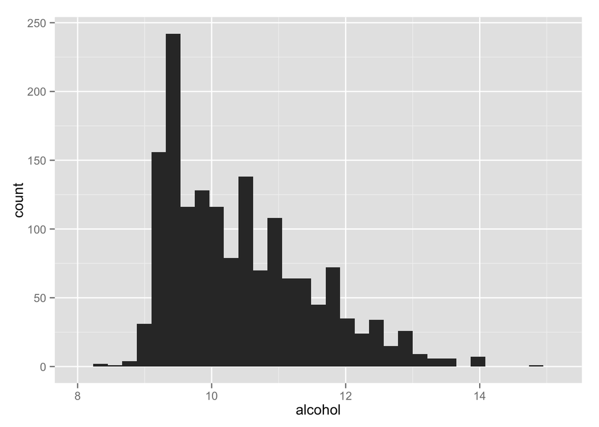

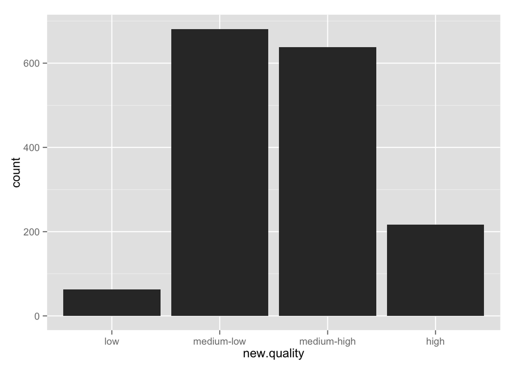

New.quality plot shows that most wines have rating of ‘medium-low’ or medium-high’ ratings.

# Next I would like to modified specsifications for histograms of residual sugar, chlorides and sulphates. I will also apply log10 transformation to residual sugar and sulphates.

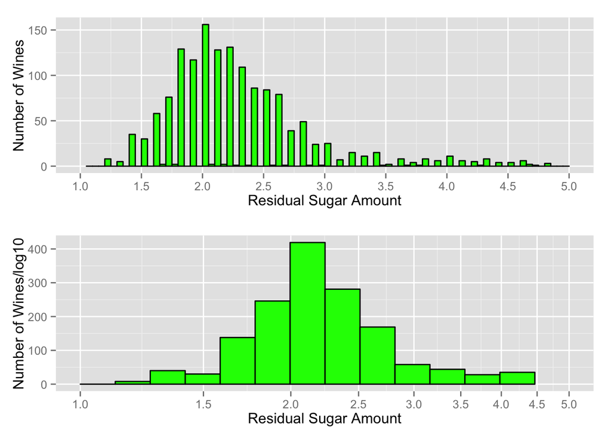

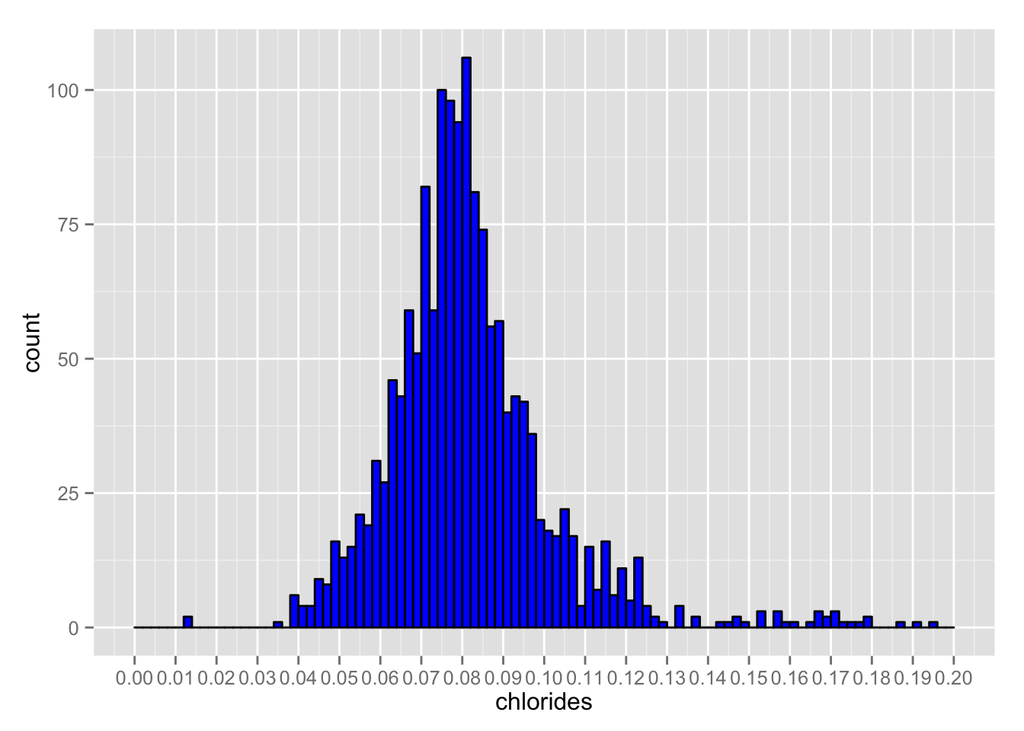

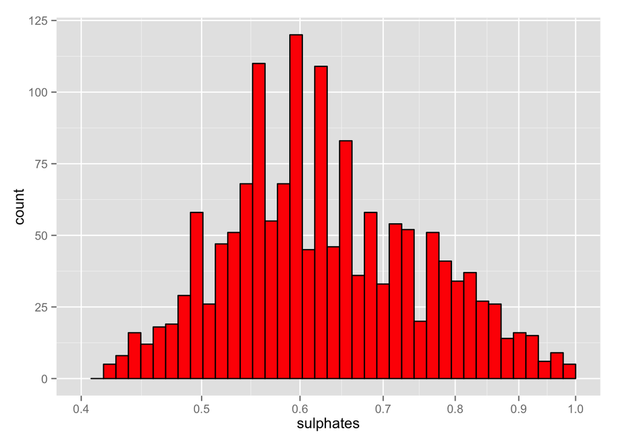

# Univariate Analysis

### What is the structure of your dataset?

This dataset consists of 12 variables and 1,599 observations. All of them are numeric variables or interger except quality.

Numeric or Interger: `fixed.acidity`,`volatile.acidity`, `citric.acid`, `residual.surgar`, `chlorides` `free.sulfur.dioxide`, `total.sulfur.dioxide`, `density`, `pH`, `sulphates`, `alcohol`

Important factor: Worst - - - - - - - - - - - - - - > Best `quality`: 0, 1, 2, 3, 4, 5, 6, 7, 8, 9, 10

Other Observation: All wines are acidic. Mediam alcohol content is 10.2% Amount of sulfur dioxide varies greatly. Density of wines has very little variation.

### What is/are the main feature(s) of interest in your dataset?

The main feature of interst in this dataset is wine `quality` and `alcohol`. I want to build a model that predicts wine quality using alcohol content and some other variables.

### What other features in the dataset do you think will help support your investigation into your feature(s) of interest?

`pH` level and `volatile.acidity` might help in predicting wine quality.

### Did you create any new variables from existing variables in the dataset?

Yes, I created combined.sulfur.dioxide varible that is the sume of free.sulfur.dioxide and total.sulfur.dioxide. Although I have doubt whether creating this new variable is nessessary or not.

### Of the features you investigated, were there any unusual distributions? Did you perform any operations on the data to tidy, adjust, or change the form of the data? If so, why did you do this?

Yes. 1. I changed ‘quality’ to factor and covert 3 and 4 to low, 5 to medium-low, 6 to medium-high, 7 to high and 8 to high. I did it because 3, 4, 7 and 8 have very few observations. 2. I applied log10 to tramsoform residual sugar’s long-tail distribution.

# Bivariate Plots Section

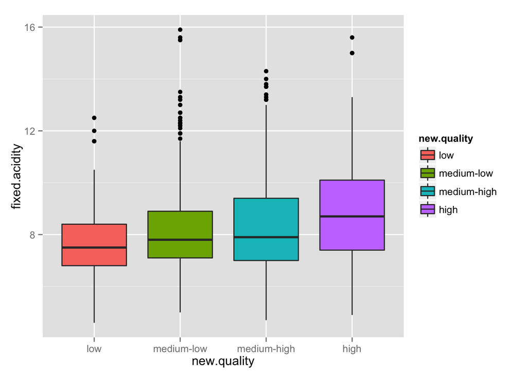

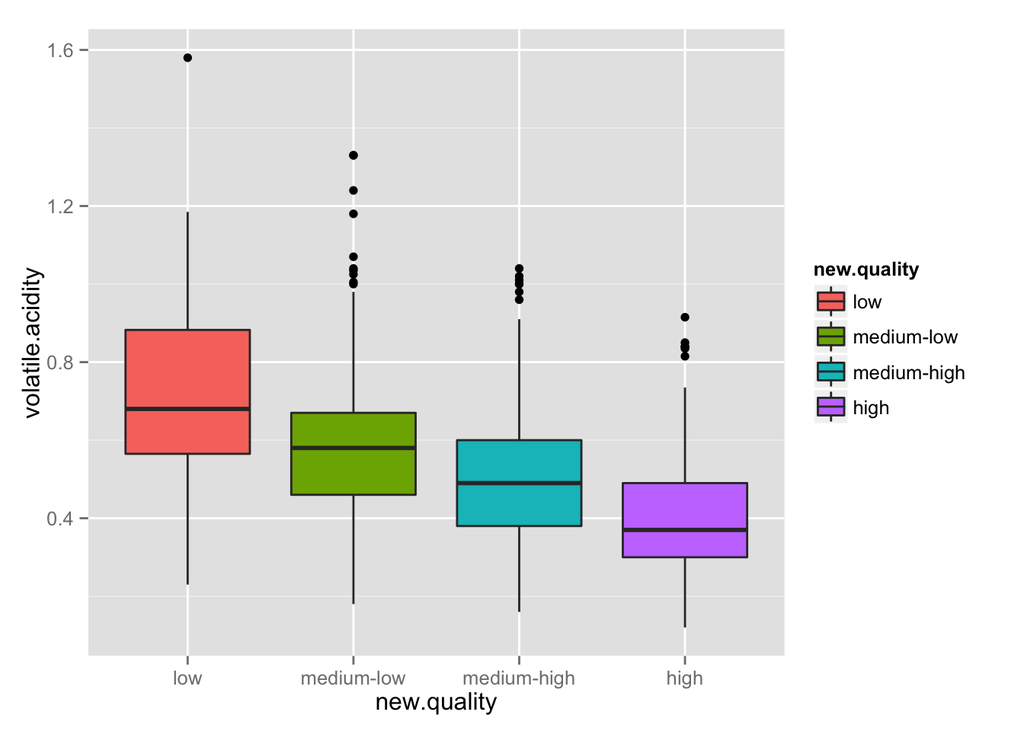

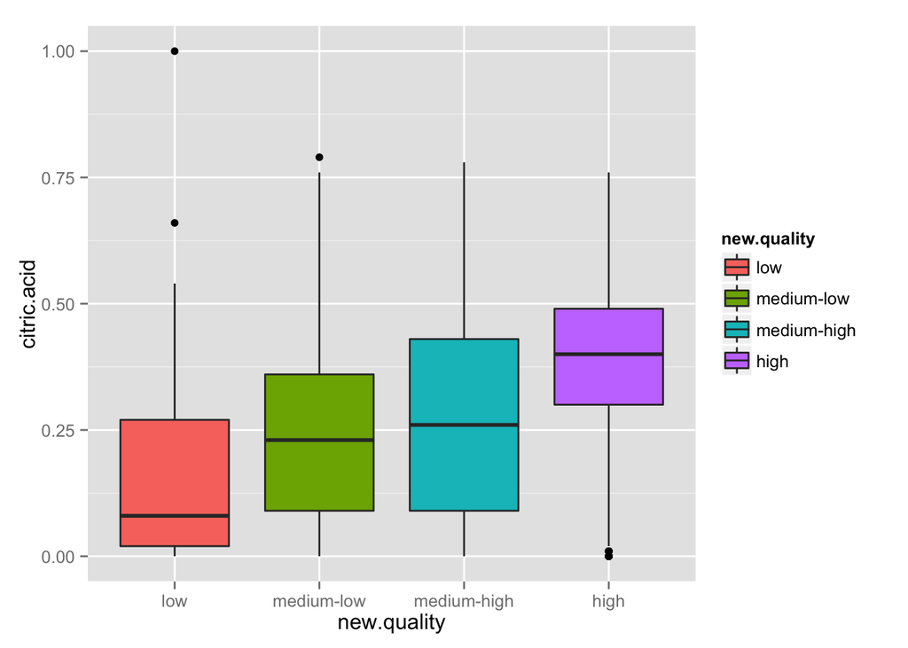

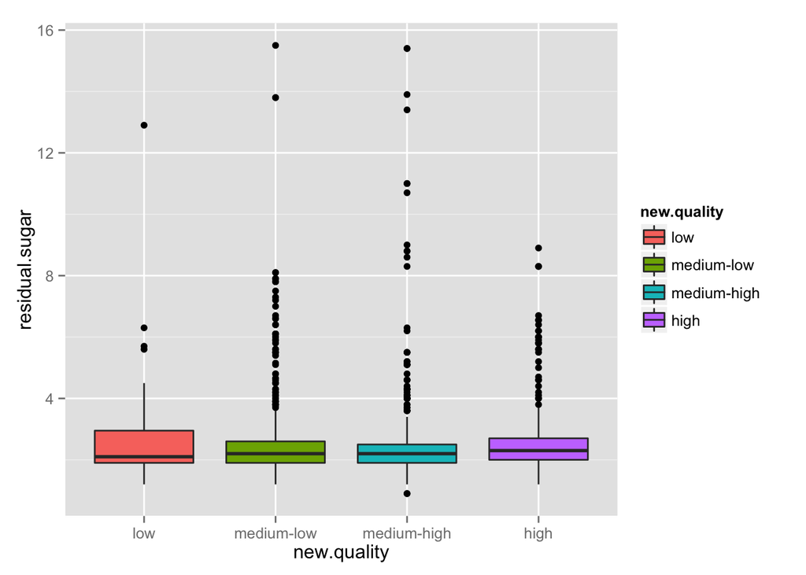

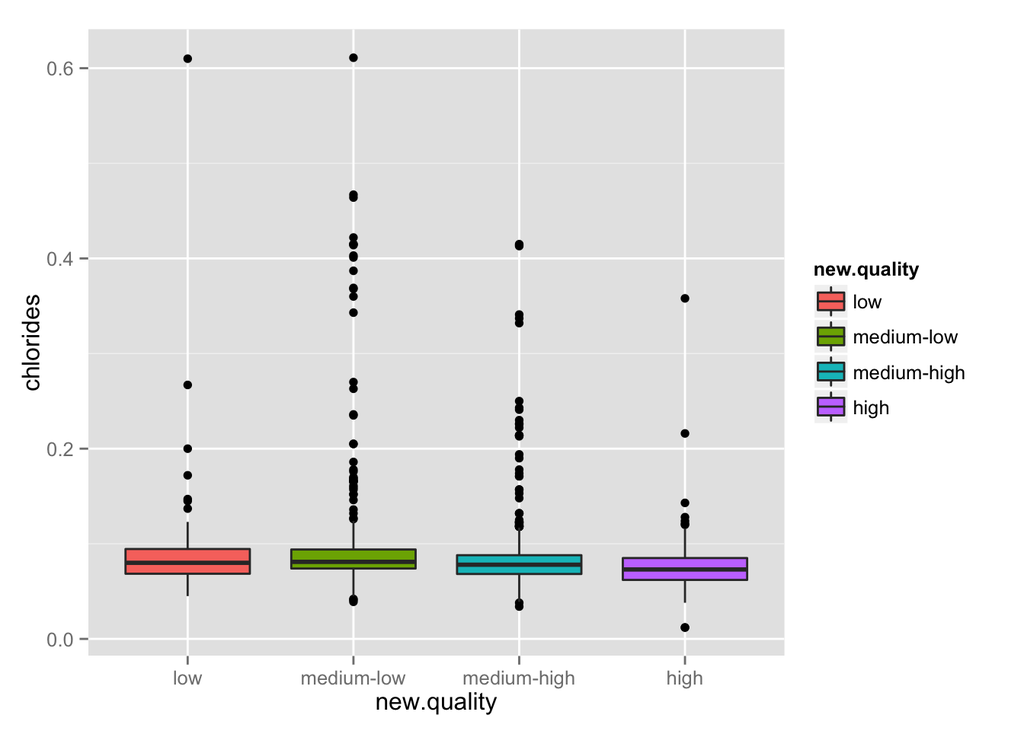

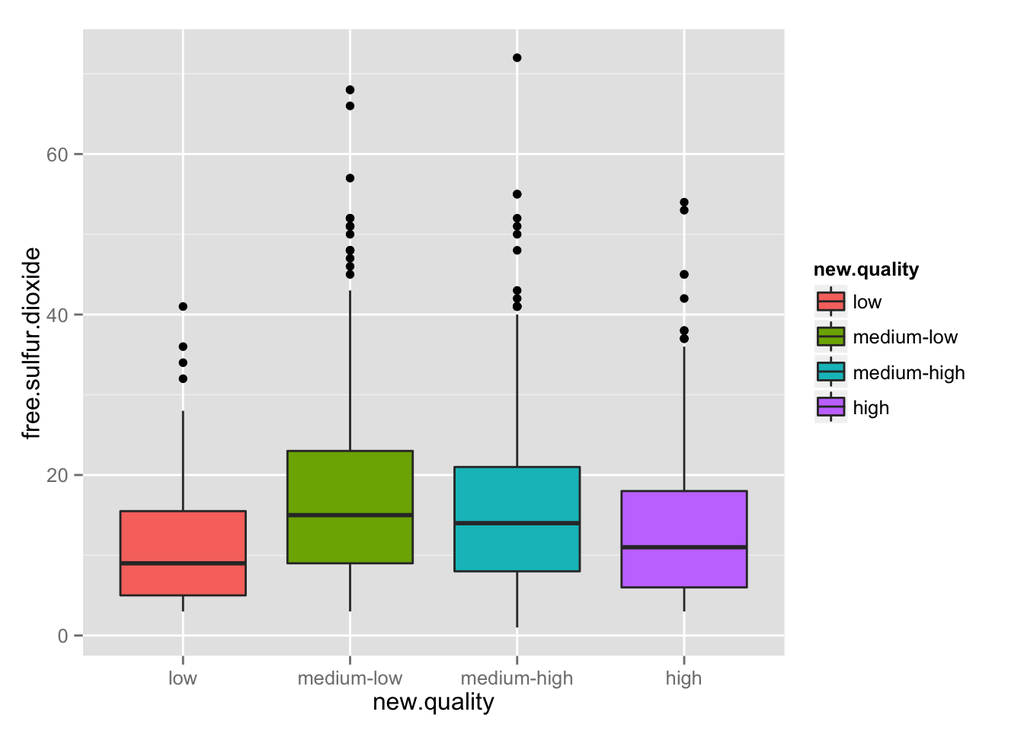

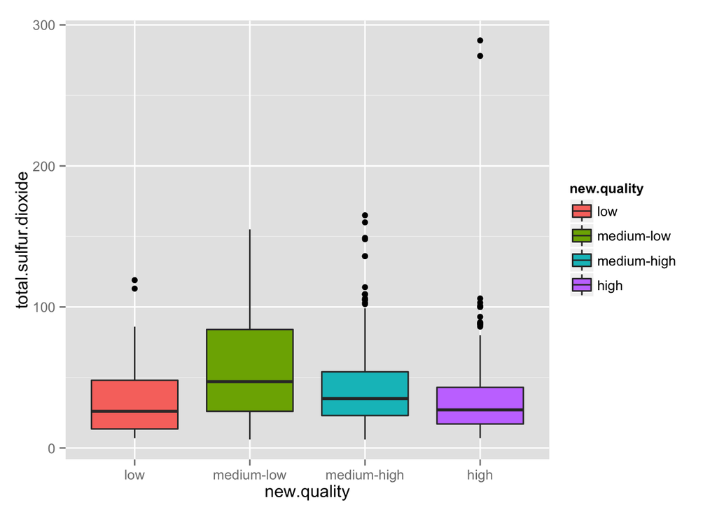

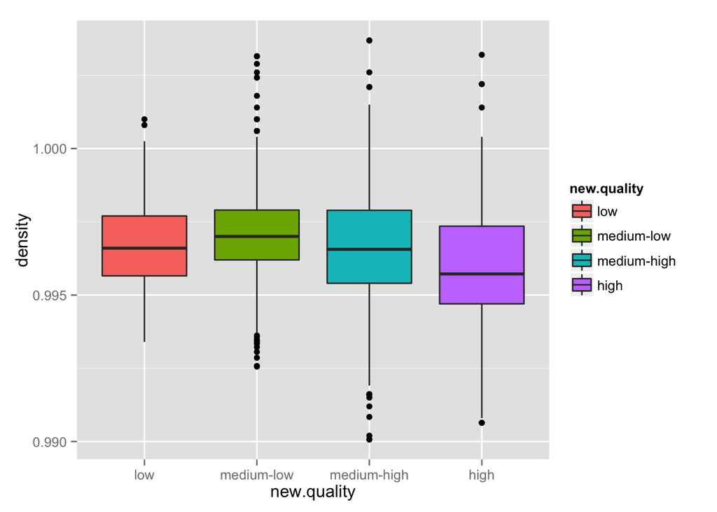

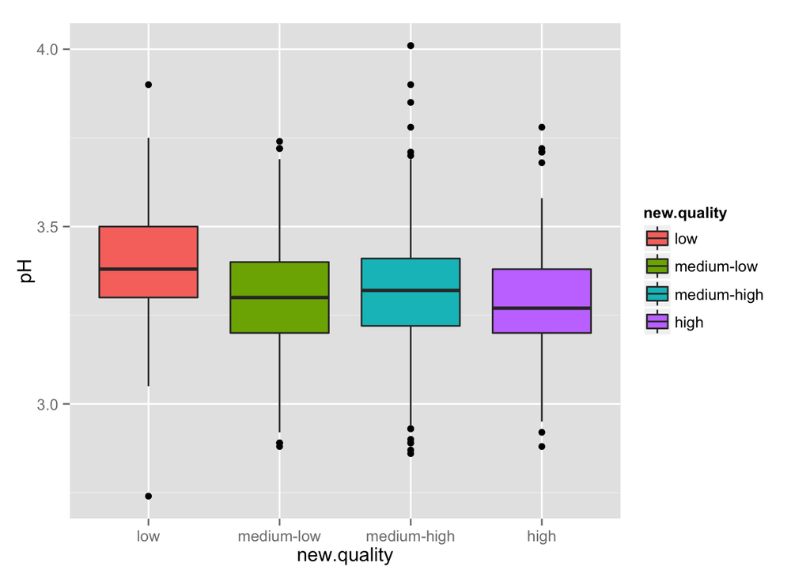

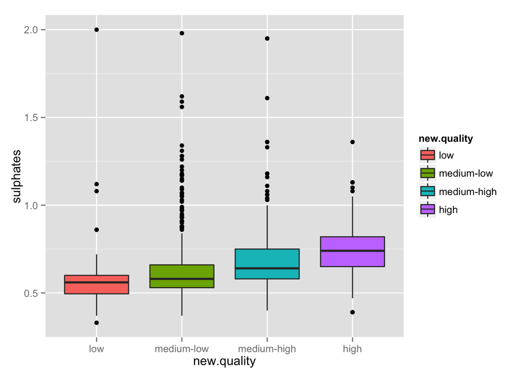

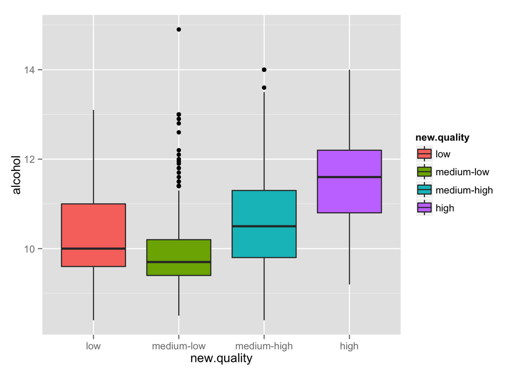

```
##
##  Pearson's product-moment correlation
##
## data:  fixed.acidity and volatile.acidity
## t = -10.589, df = 1597, p-value < 2.2e-16
## alternative hypothesis: true correlation is not equal to 0
## 95 percent confidence interval:
##  -0.3013681 -0.2097433
## sample estimates:
##        cor
## -0.2561309
```

```
##
##  Pearson's product-moment correlation
##
## data:  fixed.acidity and citric.acid
## t = 36.234, df = 1597, p-value < 2.2e-16
## alternative hypothesis: true correlation is not equal to 0
## 95 percent confidence interval:
##  0.6438839 0.6977493
## sample estimates:
##       cor
## 0.6717034
```

```
##
##  Pearson's product-moment correlation
##
## data:  fixed.acidity and sulphates
## t = 7.439, df = 1597, p-value = 1.648e-13
## alternative hypothesis: true correlation is not equal to 0
## 95 percent confidence interval:
##  0.1351974 0.2299638
## sample estimates:
##       cor
## 0.1830057
```

```
##
##  Pearson's product-moment correlation
##
## data:  volatile.acidity and citric.acid
## t = -26.489, df = 1597, p-value < 2.2e-16
## alternative hypothesis: true correlation is not equal to 0
## 95 percent confidence interval:
##  -0.5856550 -0.5174902
## sample estimates:
##        cor
## -0.5524957
```

```
##
##  Pearson's product-moment correlation
##
## data:  volatile.acidity and sulphates
## t = -10.804, df = 1597, p-value < 2.2e-16
## alternative hypothesis: true correlation is not equal to 0
## 95 percent confidence interval:
##  -0.3060917 -0.2147125
## sample estimates:
##        cor
## -0.2609867
```

```
##
##  Pearson's product-moment correlation
##
## data:  citric.acid and sulphates
## t = 13.159, df = 1597, p-value < 2.2e-16
## alternative hypothesis: true correlation is not equal to 0
## 95 percent confidence interval:
##  0.2678558 0.3563278
## sample estimates:
##     cor
## 0.31277
```

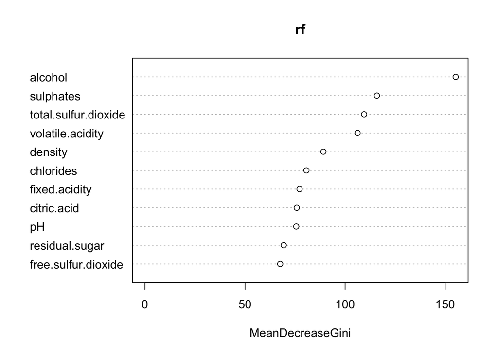

Above I used boxplot to represent the relationship of each variable with our target variable ‘Wine Quality’. I also use Pearson coorelation test to quantatively identify variables with high importance which will be discussed in details in next section.

# Bivariate Analysis

### Talk about some of the relationships you observed in this part of the investigation. How did the feature(s) of interest vary with other features in the dataset?

It seemed to me that `fix.acidity`, `volatile.acidity`, `citric.acid` and `sulphate` have some degrees of coorelation with wine quality (`new.quality`).

I then wanted to see if those features have coorelation between each other by using cor.test function.

### What was the strongest relationship you found?

Because quality is a vector, I used randomforest and its importance graph to find the variable with the strongest relationship and I found `alcohol` top the list.

# Multivariate Plots Section

Here I will plot Multivariate plots of new.quality and two other important variables.

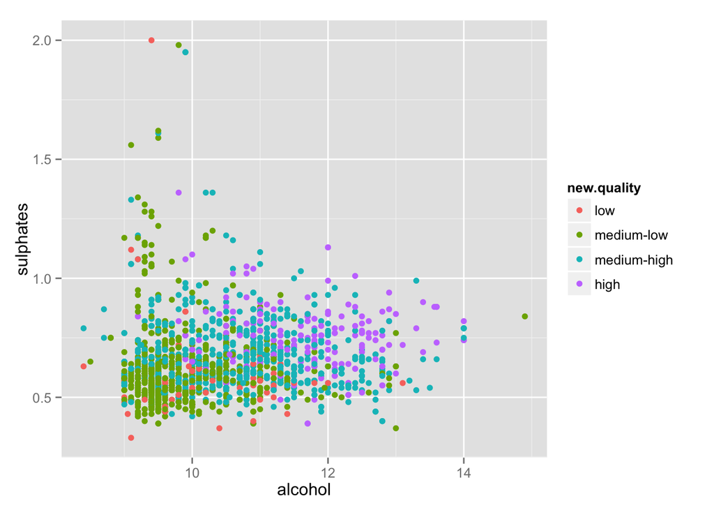

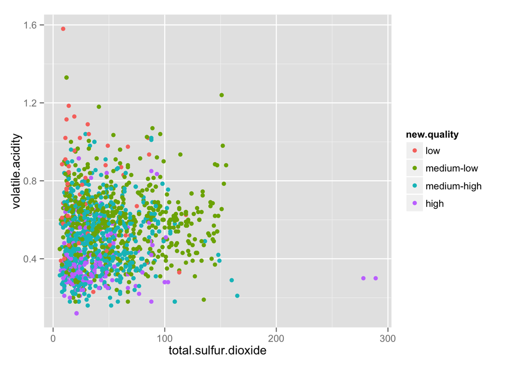

# Multivariate Analysis

I created a random forest model to predict the quality of wines. I choose random forest because it works with vector as target variable and it is easy to implement. One limitation is that it often produced misleading result if there are highly coorealted variables.

# Final Plots and Summary

### Plot One

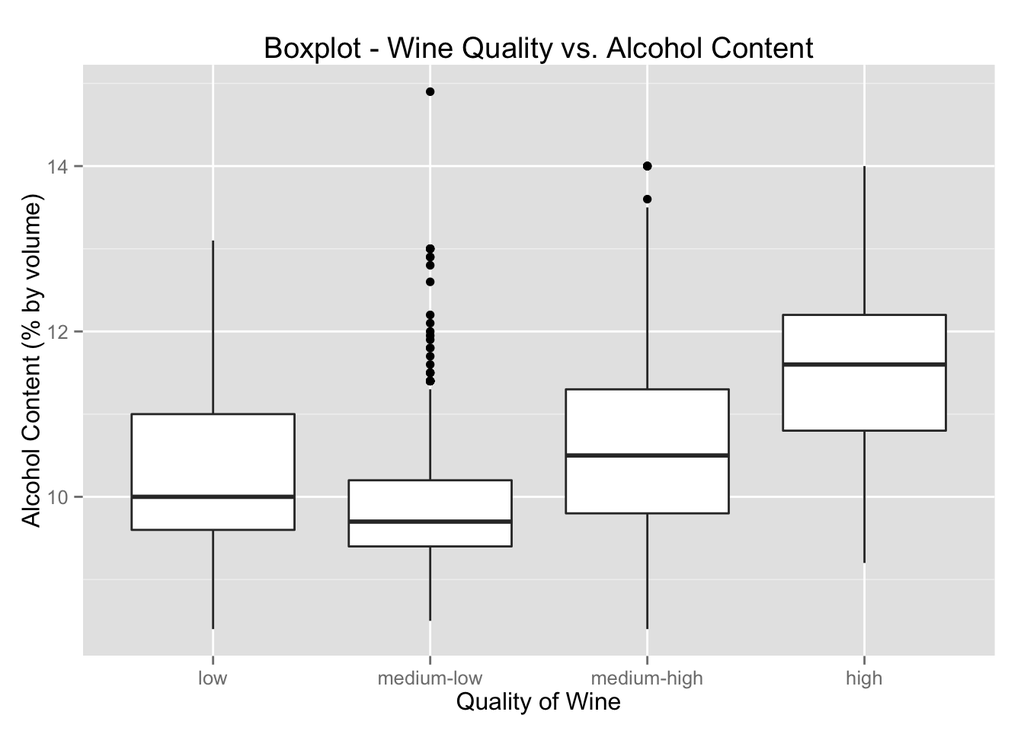

### Plot Two

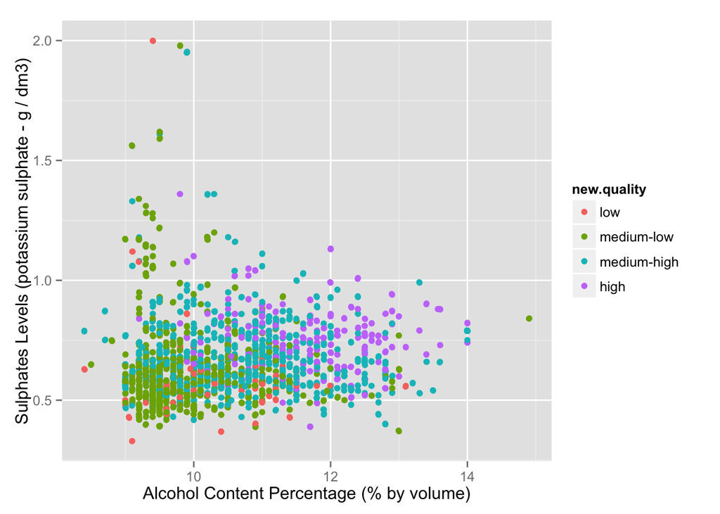

### Plot Three

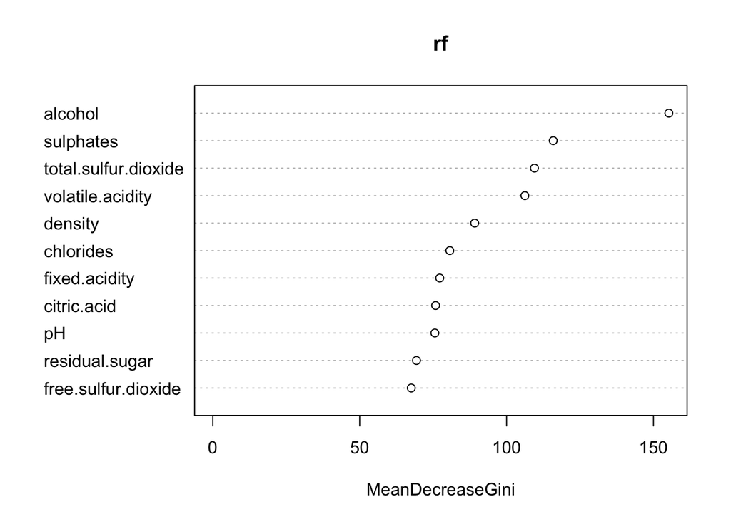

### Description Three

With the results from random forest model, we can identify the most important variable being alcohol, followed by sulphates, total.sulfur.dioxide and volatile.acidity.

# Reflection

Here in this excersise, I have examined this red wine quality data set through various plotting and different statistical techniques. While I have identified two most important features as alcohol and sulphates, we have to also recognize that these ratings are measured by wine experts and it could be that those people happen to have a perference to wines with high alcohol content. Just like people say, ‘correlation does not imply causation’.